# Final Exam of IR 2023 1st

## FINAL EXAM

### 1. merge algorithm for a binary boolean query

### 2. query optimization with postings sizes (i.e., term frequencies)

### 3. Compute set similarity (e.g., Jaccard and Cosine)

### 4. Postings list compression: Gap encoding, Gamma code.

### 5. Text classification with Naive Bayes

### 6. Text classification with Rocchio classification

### 7. WAND scoring

### 8. Precision and Recall

## 일반 개념

### 1. 정보검색의 개념

현재 인류사회의 최첨단 기술로 활용되고 있는 CHAT GPT나 Google 등은 정보검색으로 수십조가 넘는 부가가치를 창출하고 있다. Salton은 정보검색을 "정보의 구조, 분석, 조직, 저장, 탐색, 검색에 관한 분야"라고 정의했다.(Salton, 1968)

### 2. 정보검색의 역사

세계 최초의 인터넷 검색 엔진은 1990년 개발된 아키 검색 엔진이었다. 1991년 다단계 정보분류 통신규약인 고퍼가 성장하면서 베로니카와 저그헤드라는 새로운 프로그램이 생겨났다. 1993년 첫 번째 웹 로봇으로는 MIT의 매튜 그래이가 만든 웹 완더러로 알려져 있다. 웹 세상의 크기를 측정하기 위해 개발된 것으로 완덱스라는 웹 문서 색인을 만들었다. 두 번째 엔진은 같은 해 겨울에 등장한 알리 웹인데, 알리 웹은 웹 로봇을 쓰지 않고 웹사이트 운영자가 등록하는 형태였다. 비슷한 시기에 나온 점프스테이션은 웹 로봇으로 문서를 찾은 뒤 색인을 했고, 검색어 넣는 프로그램도 웹으로 만들었다. 1994년 라이코스가 상업적 성공을 거두면서 수많은 검색 엔진들이 등장해서 경쟁하기 시작했다. 1995년에는 다른 검색 엔진 서비스 회사들의 검색결과를 실시간으로 가져와 검색하는 메타 검색 엔진이 등장했다. 우리나라의 코시크였다. 1998년 키워드를 파는 검색 엔진 사업으로 구글이 큰 성공을 하게 된다. 2000년 페이지랭크 알고리즘으로 시장을 과점한다. 검색 엔진 인터페이스를 최소화시켜 유지한 것도 특색이다. 최근에는 키워드에서 의미 기반 검색 기법이 활용되고 있다.

### 3. 정보검색 기술의 구조

검색엔진은 문서 수집 - 색인 - 검색의 순서로 동작한다. 웹 스파이더(웹 크롤러)가 웹사이트의 모든 링크를 따라다니면서 문서를 모으고, 색인을 위해 분석되며, DB에 적절히 색인된다. 검색어가 들어오면 정보를 빨리 찾도록 한다.

- 색인은 문서를 마크하고, 문서에 있는 모든 단어를 단어단위로 잘라 토큰화를 하여, 물론 이때 불필요한 요소들을 없애는 정규화를 먼저 한다, 토큰화 한 단어가 어떤 문서에 들어 있는 지, 문서에 그 단어가 몇 번 들어 있는지의 빈도를 표시하여 한다.
- 예를 들어, 1번 부터 100번 까지의 문서에서 "A"라는 단어가 9 30 57 88 99 번 문서에 있었다고 하면, A는 9, 30, 57, 88, 99가 된다. 이때, A라는 단어가 그 문서에서 얼마나 중요하게 다루어 졌느냐로 나중에 우선 제시하는 비교지표를 만들기 위해 빈도를 넣어 줄 수 있다. 즉 A : 9-5, 30-1, 57-8, 88-2, 99-10 과 같이 색인할 수 있다. 또는 A : 99999305757575757575757888899999999999999999999가 될 수 있다. 이러한 단어들의 색인을 모아놓은 것이 Postings lists이다.
- 일반적으로 문서에 있는 단어를 색인 하는 것을 색인이라고 했는데, 위와 같이 다시 단어를 문서로 색인하기 때문에 역 색인이라고 한다.

### 1. merge algorithm for a binary boolean query

- 검색엔진은 검색어가 들어왔을 때 정보를 빨리 찾기 위해서 색인을 한정하는 것이 매우 효과적이다. "A"라는 단어를 포함한 문서가 100개 "B"라는 단어를 포함하는 문서가 100개, 이중 둘다 포함하는 단어가 10개라고 하면, 각각의 단어를 검색한다면 100개의 문서를 보여주어야 하고, 이는 랭킹도 되어 있지 않아 어떤 문서를 먼저 보여주어야 할 지 모른다. 이때 "A 와 B"를 검색하면 단 10개만 보여 주면 된고, 검색하는 사람도 필요했던 자료에 더욱 가까워 진다.
- 이렇게, 단어 간의 논리 연산을 통해 참, 거짓의 두 가지 원소로만 존재하는 집합에서의 연산을 boolean 연산이라고 한다. 두 개를 대상으로 하면 binary가 된다. 연산을 할때는 연산을 일으키는 연산자가 있어야 하는 데, 'AND', 'OR', 'NOT'등이 있다.
- 색인된 단어 "A"와 "B"를 논리 연산을 통해 적당한 문서를 찾아주려면(A : 9, 30, 57, 88, 99, B : 30, 44, 67, 88, 91) A AND B의 경우 (9, 30 : F) ~ (9, 96 : F), (30, 30 : T), (57, 67 : F) ~ (57, 96 : F)**, (88, 88 : T)가 되어 : 30, 88이 된다.

  ** 57이 B의 다음 docID인 44보다 크므로 67을 검색

  마찬가지의 방법으로, A OR B의 경우 : 9, 30, 44, 57, 67, 88, 91, 99가 된다. A NOT B의 경우 : 9, 57, 99가 된다.

  처음에 Merge할 빈리스트를 만들어 선택된 것만 립스트에 담으면 논리연산에 의한 머지된 새로운 포스팅이 생긴다. 이렇게 두 단어의 postings를 병합하는 것을 Merge Algorithm이라고 한다.

  이때, 효율적인 Merge를 하려면 역색인 길이가 짧은 것을 기준으로 하는 것이 좋다.

### 2. query optimization with postings sizes (i.e., term frequencies)

- 효율적인 Merge를 하려면 역색인 길이가 짧은 것을 기준으로 하는 것이 좋다. **예를 들어 "A" : 210 이고 "B" : 256789라고 하면, A를 기준으로 하면 2번이면 끊나지만 B로 하면 9까지 다 점검을 해야 한다.** 특히, 여러 개의 단어에 대해 논리 연산을 하고자 할 때 유용하다. 제일 적은 수의 조합을 먼저 논리연산을 하고, 그 다음 것으로 넘어간다.

### 3. Compute set similarity (e.g., Jaccard and Cosine)

- 집합 유사도(셋 유사도)는 두 개의 집합 간의 유사성을 측정하는 방법이다. 대표적인 집합 유사도 메트릭으로는 Jaccard 유사도와 Cosine 유사도가 있다.
- Jaccard 유사도: Jaccard 유사도는 두 개의 집합 A와 B 사이의 공통된 요소의 비율을 계산하여 유사성을 측정합니다. Jaccard 유사도는 다음과 같은 공식으로 계산된다. :

J(A, B) = |A ∩ B| / |A ∪ B|

여기서 |A|는 집합 A의 크기를 나타내며, ∩는 교집합을, ∪는 합집합을 나타냅니다. Jaccard 유사도는 0과 1 사이의 값을 가지며, 1에 가까울수록 유사성이 높다고 판단한다. Jaccard 유사도는 집합의 원소들 사이의 관계를 고려하는 간단하면서도 효과적인 메트릭이다.

- Cosine 유사도: Cosine 유사도는 벡터 공간에서 두 개의 벡터 사이의 각도를 계산하여 유사성을 측정합니다. 집합을 벡터로 표현할 수 있을 때, Cosine 유사도는 두 벡터 사이의 코사인 값으로 계산됩니다. Cosine 유사도는 다음과 같은 공식으로 계산된다.

Cosine(A, B) = (A ∩ B) / (||A|| * ||B||)

여기서 A ∩ B는 두 벡터의 내적을 나타내며, ||A||와 ||B||는 각각 벡터 A와 벡터 B의 크기(노름)를 나타냅니다. Cosine 유사도는 -1과 1 사이의 값을 가지며, 1에 가까울수록 유사성이 높다고 판단합니다. Cosine 유사도는 벡터의 방향과 크기를 모두 고려하여 유사성을 측정하는데 사용된다.

- x = {a, b, c, d, e}, y = {b, c, d, e, f}일 떄, 두 데이터 셋의 유사도는 어떻게 될까? 유사하다는 것은 같은 것이 많다는 것이다. 여기서 같은 것은 n(x and y) = 4이다. **그럼 기준은 무엇인가? Jaccard 유사도는 n(x or y) = 6이다. 그래서 4/6 = 0.67이다.** 코싸인 유사도의 기준은 루트 |A| *|B| 이다. 즉 루트 5*5 = 루트 25 = 5이다. 그래서 4/5 = 0.8이다.

### 5. Text classification with Naive Bayes.

- Text classification은 전통적으로 Yahoo 등에서 수동으로 분류하는 방법, IDE 처럼 사람 손으로 코딩을 해서 규칙에 맞게 분류하는 방법, 지도학습이다.
- 이중 지도학습은 나이브 베이지안, KNN이라고 불리는 k-Nearest Neighbors, Support-vector machines, Decision trees, random forests, gradient-boosted decision trees 등이 있다. 많은 상용 시스템은 이런 방법들을 혼용해서 쓴다.
- 자연어의 경우 gamma([great : 2, love : 2]) = c와 같이 된다.
- 그런데, 자연어 모음은 백만개 이상의 고유한 단어들이 많아 변수가 너무 많다. 변수가 많으면, traing time이 너무 오래 걸리고, 모델의 구동시간을 적게 하며, 빠르게 한다.
  - 노이즈를 삭제하고, 오버피팅을 피하기 위해 일반화를 한다.
  - 또한, 가장 간단한 변수선택방법은 빈도이다.
  - chi-squared 같은 더 효과적인 변수선택도 있다.
- 베이지안 추론 P(A|B)는 A사건과 B사건에서 B에 대해 두 사건이 동시에 일어날 확률 (A and B)이다. 즉, P(A and B)/P(B) ** 본질은 입장바꿔생각하는 것이다. A given B를 B given A로 풀어내는 것 P(A|B) = P(A∩B)/P(B), P(B|A) = P(A∩B)/P(A), P(A∩B) = P(A|B)P(B) = P(B|A)P(A), P(A|B) = P(B|A)P(A)/P(B)
- 나이브 베이지안 추론은 베이지안을 모델을 쓰지만, 변수간 서로 독립적이라는 가정을 하는 것이다. 용어끼리 독립적이지 않은 경우가 많지만, 그렇게 정의하는 것이다. c map = argmax P(c|d) = argmax P(c)P(d|c)/P(d) = argmax P(c)P(d|c) 최대값이므로 p(d)는 일정하니까 분자만 고려한다.

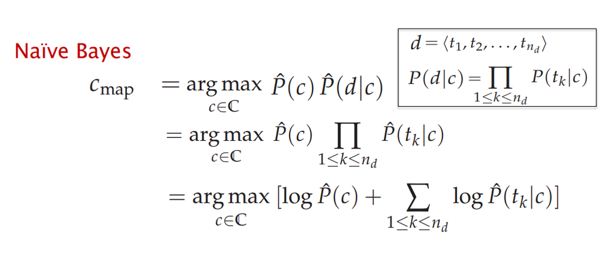

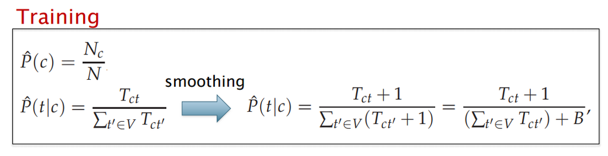

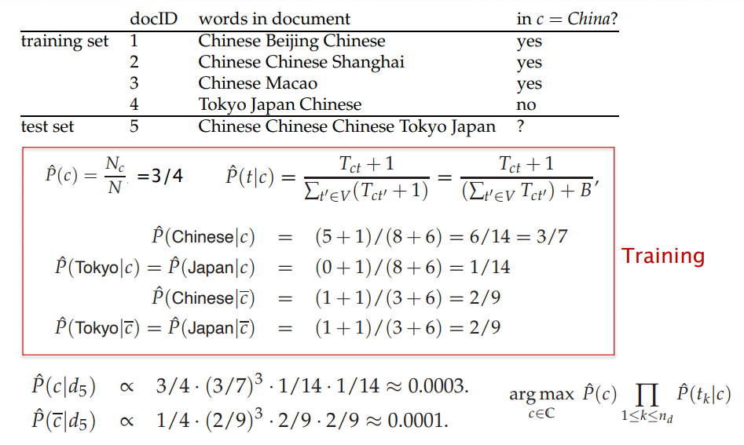

test set에서 chinese 3개 tokyo japan 각 1이므로 ^p(c|d5) chiness 확률 3번, 도쿄 한번, 자펜 한번, 아닐 확률도 마찬가지

### 6. Text classification with Rocchio classification.

- 로치오 분류는 Vector Space Model에 기반한 분류 방법으로 문서의 특징 택터와 각 틀래스의 대표 벡터 사이의 거리로 분류를 수행한한다.
1. 대표 벡터를 계산한다. : 해당 클래스에 속하는 모든 문서 벡터의 평균 벡터
2. 분류모델 학습
3. test 문서 특징 벡터 계산
4. 특징 벡터와 각 클래스의 대표 벡터 사이 거리 계산, 유클리드 거리나 코아인 유사도
5. 가장 가까운 클래스로 문서 분류

자연어 분류에만 최적합.

### 7. WAND scoring(Weighted AND)

- 문서 속성을 고려한 텍스트 매칭을 위한 점수화 기법인 DAAT scoring의 일종 이다.
- 임계값을 정하고 임계값 이하의 코사인 점수는 버리고, 남아 있는 것만 코사인 점수를 매긴다.
- WAND 색인 구조
  - 문서ID로 포스팅 - UB는 Upper bounds

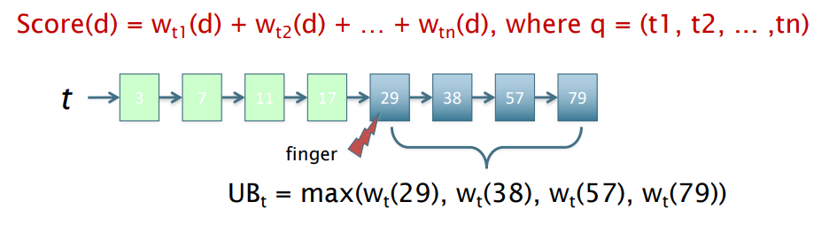

  - 남아있는 문서에서 가장 큰 값을 유지하여, 불필요한 계산을 줄임

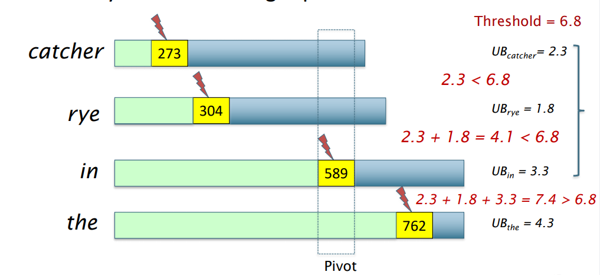

  UB 점수의 합이 임계점인 6.8을 넘을 때 아래와 같이 단어들이 핑커 포지션으로 소팅된다.

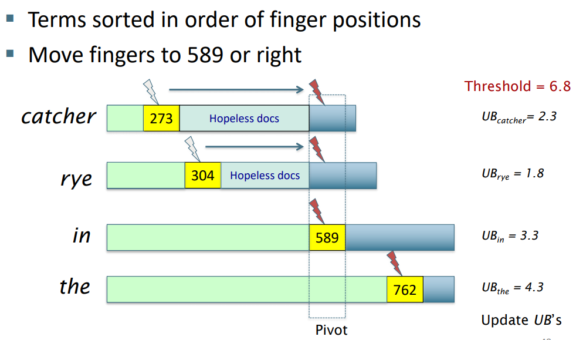

  589가 충분하다면 589 또는 그 이상을 전체 코사인 스코어로 정한다.

  WAND는 90%이상의 스코어 부하를 줄여준다.

### 8. Precision and Recall.

랭킹이 없는 검색에 대한 평가 방법

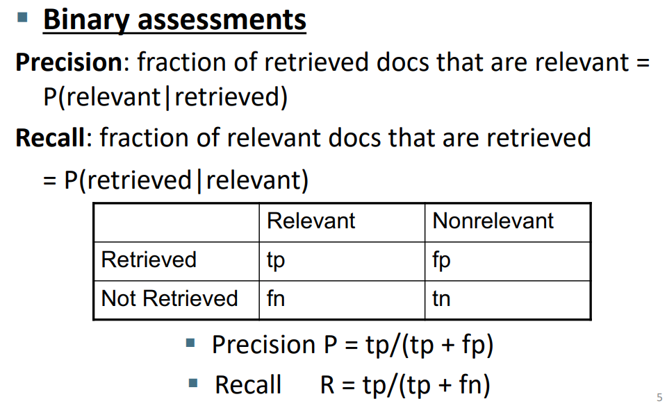

precision과 recall을 동시에 향상 시킬 수 없다.

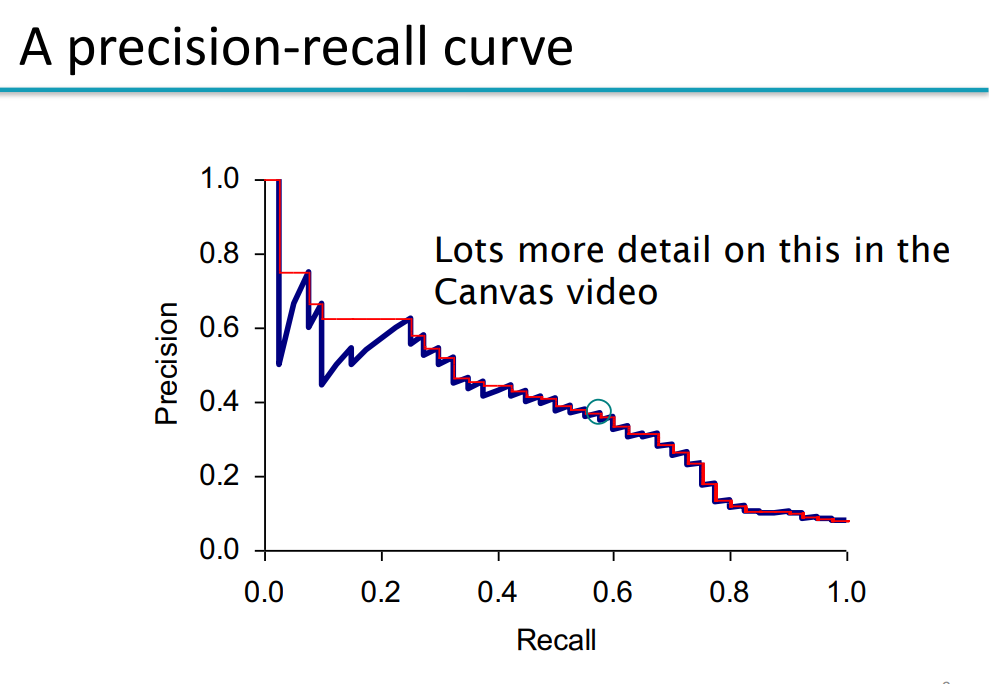

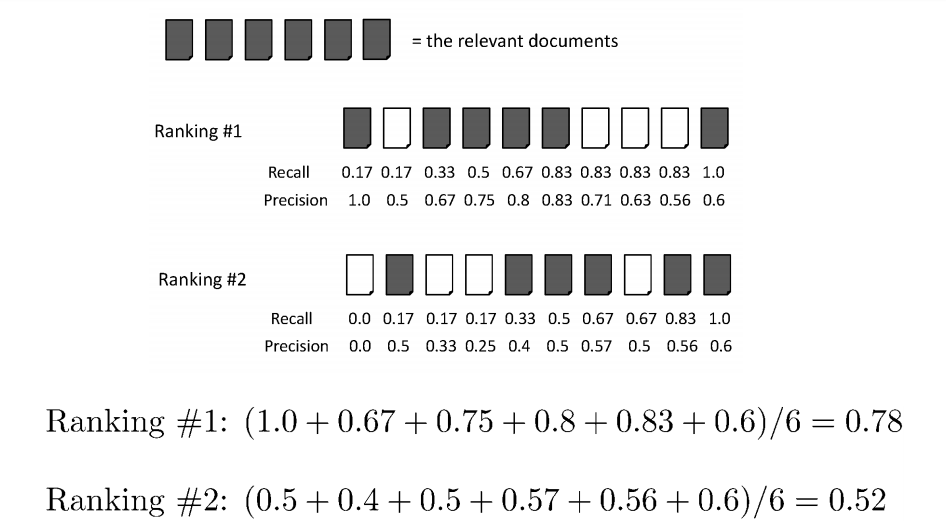

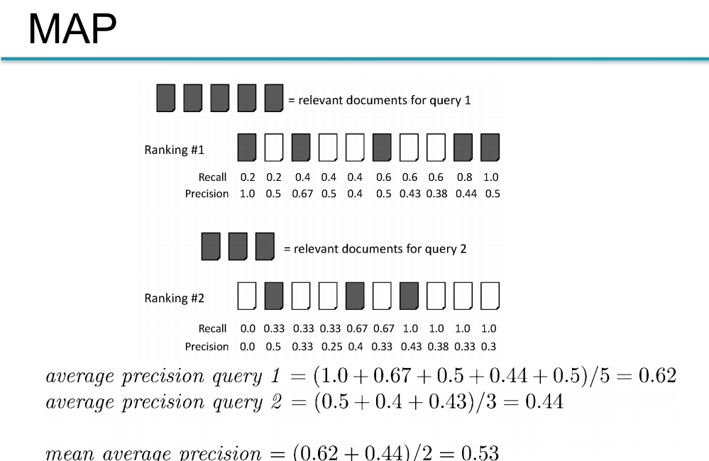

MAP = Mean average precision

```python
! pip install PyPDF2
```

```
     -------------------------------------- 232.6/232.6 kB 7.2 MB/s eta 0:00:00
```

```python
! pip install PyPDF2

import glob
from PyPDF2 import PdfReader

def search_text_in_documents():
    folder_path = input("검색할 폴더 경로를 입력하세요: ")
    search_text = input("검색할 텍스트를 입력하세요: ")

    file_paths = glob.glob(folder_path + "/*.pdf")

    for file_path in file_paths:
        try:
            with open(file_path, 'rb') as file:
                pdf = PdfReader(file)
                num_pages = len(pdf.pages)
                found = False

                for page_num in range(num_pages):
                    page = pdf.pages[page_num]
                    text = page.extract_text()

                    if search_text in text:
                        print(f"검색어 '{search_text}'를 찾았습니다. 문서: {file_path}, 페이지: {page_num + 1}")
                        found = True

                if not found:
                    print(f"검색어 '{search_text}'를 찾지 못했습니다. 문서: {file_path}")

        except Exception as e:
            print(f"오류 발생: {str(e)}")

search_text_in_documents()
```

```
검색할 폴더 경로를 입력하세요: C:\onedrive_cnu_ac_kr\OneDrive - cnu.ac.kr\알렉스김\AI\AI 동물바이오\2023\IR
검색할 텍스트를 입력하세요: recall
검색어 'recall'를 찾지 못했습니다. 문서: C:\onedrive_cnu_ac_kr\OneDrive - cnu.ac.kr\알렉스김\AI\AI 동물바이오\2023\IR\lecture10.pdf
검색어 'recall'를 찾았습니다. 문서: C:\onedrive_cnu_ac_kr\OneDrive - cnu.ac.kr\알렉스김\AI\AI 동물바이오\2023\IR\lecture11 (1).pdf, 페이지: 25
검색어 'recall'를 찾았습니다. 문서: C:\onedrive_cnu_ac_kr\OneDrive - cnu.ac.kr\알렉스김\AI\AI 동물바이오\2023\IR\lecture11.pdf, 페이지: 25
검색어 'recall'를 찾지 못했습니다. 문서: C:\onedrive_cnu_ac_kr\OneDrive - cnu.ac.kr\알렉스김\AI\AI 동물바이오\2023\IR\lecture12 (1).pdf
검색어 'recall'를 찾지 못했습니다. 문서: C:\onedrive_cnu_ac_kr\OneDrive - cnu.ac.kr\알렉스김\AI\AI 동물바이오\2023\IR\lecture12.pdf
검색어 'recall'를 찾지 못했습니다. 문서: C:\onedrive_cnu_ac_kr\OneDrive - cnu.ac.kr\알렉스김\AI\AI 동물바이오\2023\IR\lecture13.pdf
검색어 'recall'를 찾지 못했습니다. 문서: C:\onedrive_cnu_ac_kr\OneDrive - cnu.ac.kr\알렉스김\AI\AI 동물바이오\2023\IR\lecture2.pdf
검색어 'recall'를 찾지 못했습니다. 문서: C:\onedrive_cnu_ac_kr\OneDrive - cnu.ac.kr\알렉스김\AI\AI 동물바이오\2023\IR\lecture3.pdf
검색어 'recall'를 찾지 못했습니다. 문서: C:\onedrive_cnu_ac_kr\OneDrive - cnu.ac.kr\알렉스김\AI\AI 동물바이오\2023\IR\lecture4.pdf
검색어 'recall'를 찾지 못했습니다. 문서: C:\onedrive_cnu_ac_kr\OneDrive - cnu.ac.kr\알렉스김\AI\AI 동물바이오\2023\IR\lecture5.pdf
검색어 'recall'를 찾지 못했습니다. 문서: C:\onedrive_cnu_ac_kr\OneDrive - cnu.ac.kr\알렉스김\AI\AI 동물바이오\2023\IR\lecture6.pdf
검색어 'recall'를 찾지 못했습니다. 문서: C:\onedrive_cnu_ac_kr\OneDrive - cnu.ac.kr\알렉스김\AI\AI 동물바이오\2023\IR\lecture7.pdf
검색어 'recall'를 찾지 못했습니다. 문서: C:\onedrive_cnu_ac_kr\OneDrive - cnu.ac.kr\알렉스김\AI\AI 동물바이오\2023\IR\lecture8 (1).pdf
검색어 'recall'를 찾지 못했습니다. 문서: C:\onedrive_cnu_ac_kr\OneDrive - cnu.ac.kr\알렉스김\AI\AI 동물바이오\2023\IR\lecture8.pdf
검색어 'recall'를 찾았습니다. 문서: C:\onedrive_cnu_ac_kr\OneDrive - cnu.ac.kr\알렉스김\AI\AI 동물바이오\2023\IR\lecture9.pdf, 페이지: 9
검색어 'recall'를 찾지 못했습니다. 문서: C:\onedrive_cnu_ac_kr\OneDrive - cnu.ac.kr\알렉스김\AI\AI 동물바이오\2023\IR\noisy channel model.pdf
```

## 참고문헌

- G. Salton, Automatic Information Organization and Retrieval, McGraw-Hill, New York, 1968.